# Graphics in R: ggplot2

### Regression

geom_smooth or stat_smooth are methods that plot models of the data. Method and formula can be specified, confidence bands can be removed.

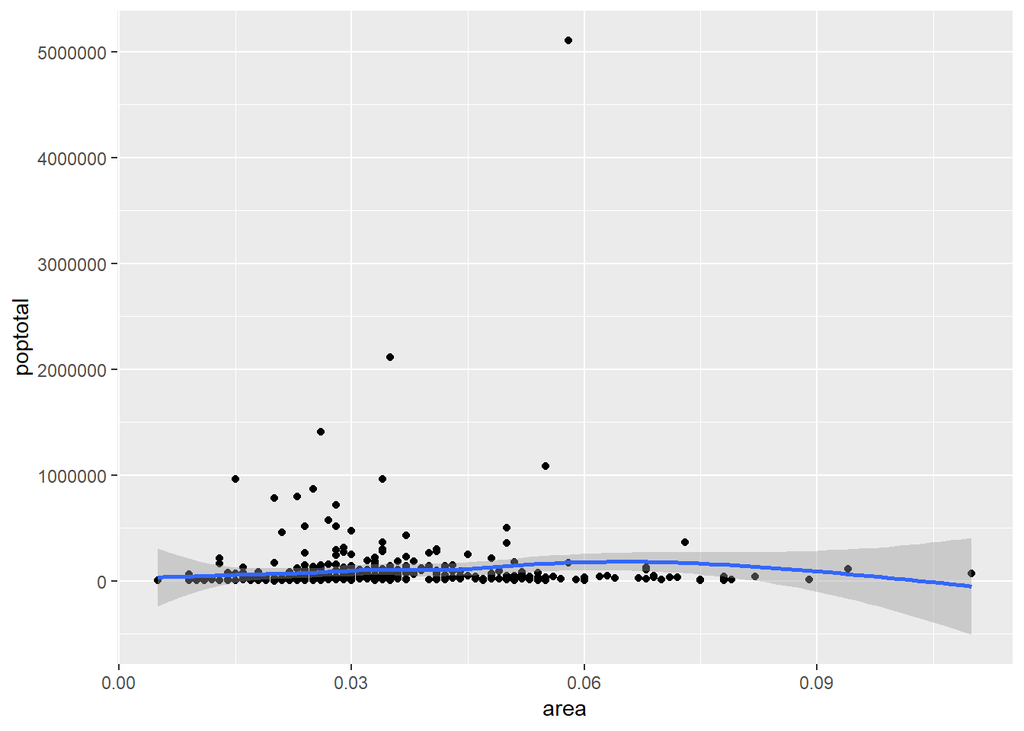

```r
ggplot(midwest,aes(x=area,y=poptotal)) + geom_point() + geom_smooth()
```

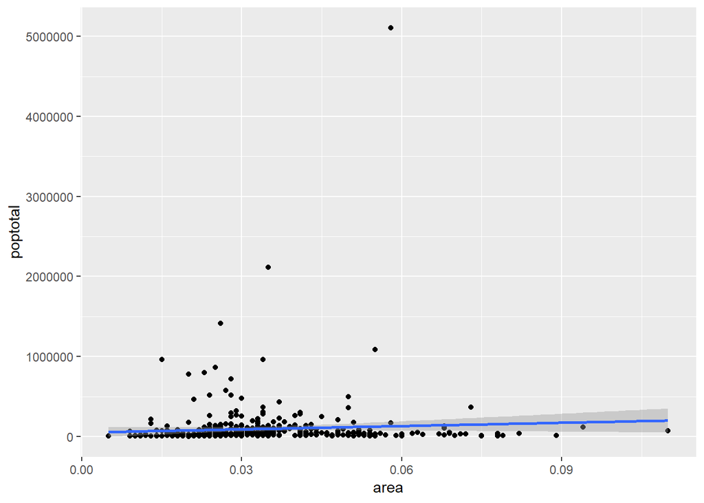

```r
ggplot(midwest,aes(x=area,y=poptotal)) + geom_point() + geom_smooth(method='lm')
```

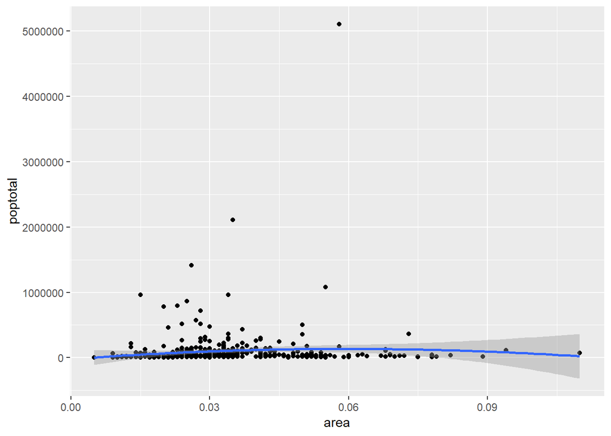

```r
ggplot(midwest,aes(x=area,y=poptotal)) + geom_point() + geom_smooth(method = 'lm', formula = 'y ~ poly(x,2)')
```

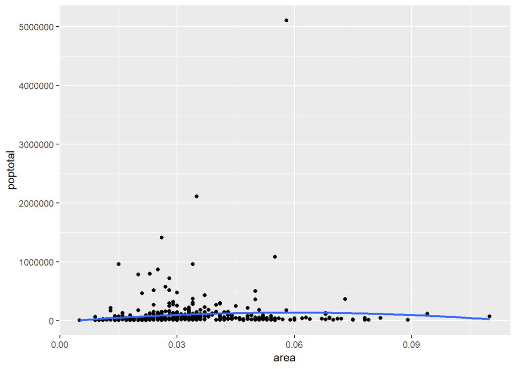

```r
ggplot(midwest,aes(x=area,y=poptotal)) + geom_point() + geom_smooth(method = 'lm', formula = 'y ~ poly(x,2)', se = FALSE)
```

### Adjusting Axes

Deleting Data vs Zooming In

1. Deleting Data: xlim() & ylim() hardcode limits of the axes

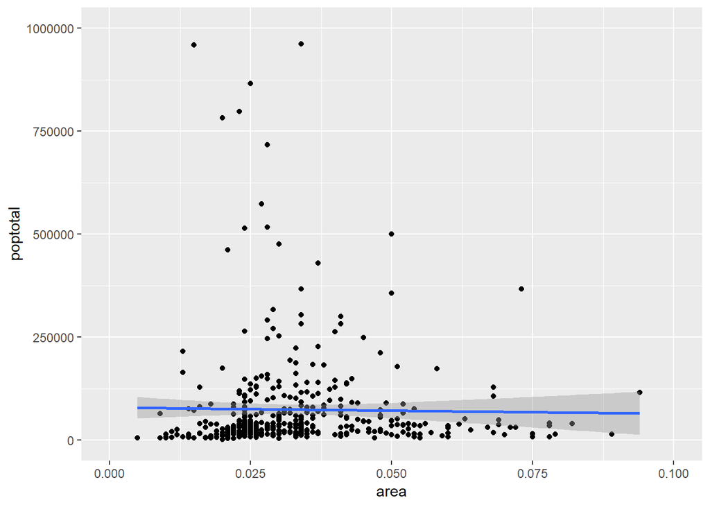

```r
g = ggplot(midwest, aes(x = area, y = poptotal)) + geom_point() + geom_smooth(method='lm')

g + xlim(c(0, 0.1) ) + ylim(c(0, 1000000))
```

2. Zooming In: coord_cartesian() retains all values of attached data to be used in stats layers but only data within provided limits are displayed

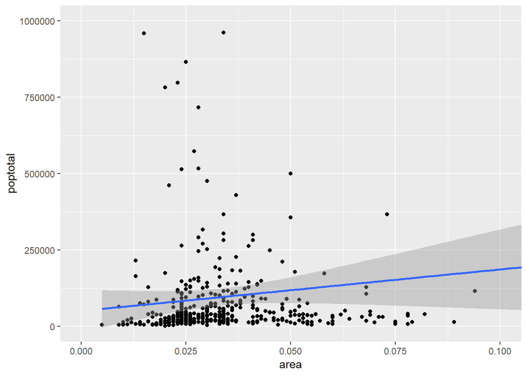

```r
g + coord_cartesian(xlim = c(0, 0.1), ylim = c(0, 1000000))
```

### Axes Labels

The functions **labs()** or **ggtitle()** with **xlab()**/**ylab()** control axes labels.

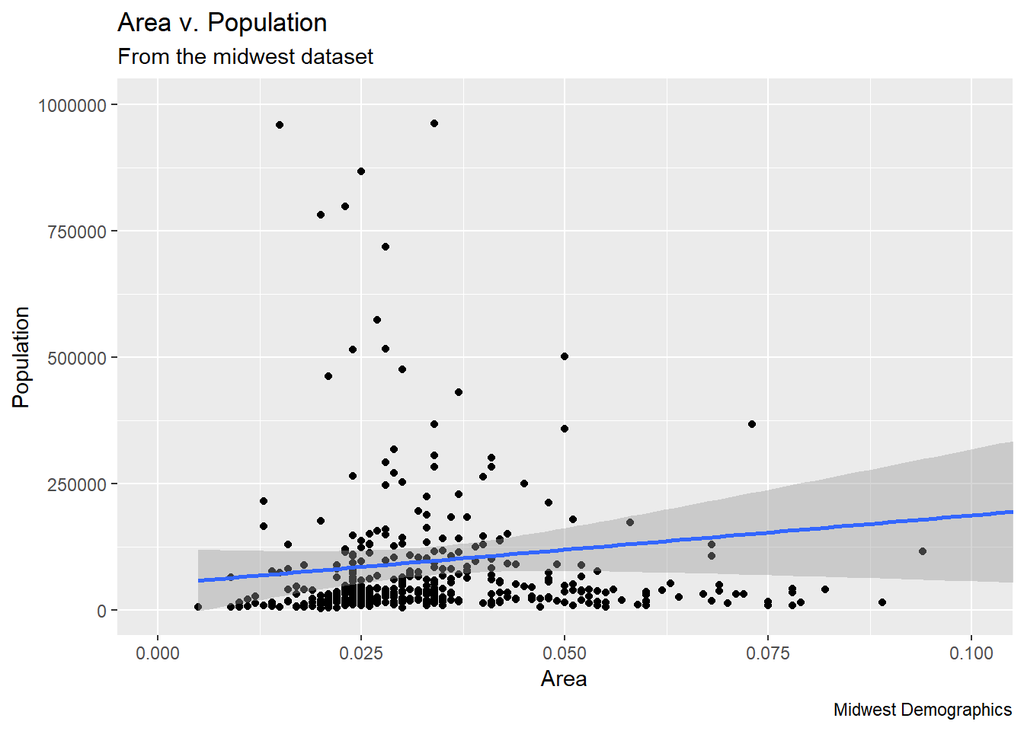

```r
# Build the Setup
g0 = ggplot(midwest, aes(x = area, y = poptotal))

# Build the Scatter and Regression Layers
g =  g0 + geom_point() + geom_smooth(method='lm')

# Build the plot with Zoom
g1 = g + coord_cartesian(xlim = c(0, 0.1), ylim = c(0, 1000000))

# Add Titles and Labels

g1 + labs(title = "Area v. Population", subtitle = "From the midwest dataset", x = "Area", y = "Population", caption = "Midwest Demographics")
```

**or**

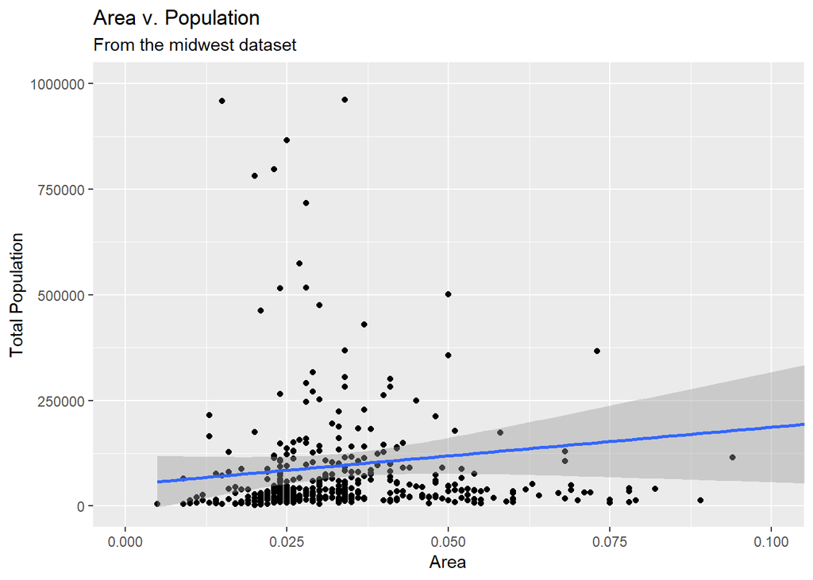

```r
g1 + ggtitle("Area v. Population", subtitle = "From the midwest dataset") + xlab("Area") + ylab("Total Population")
```

### Colors

The colors of each layer can be set within the layer depending on the geometry used:

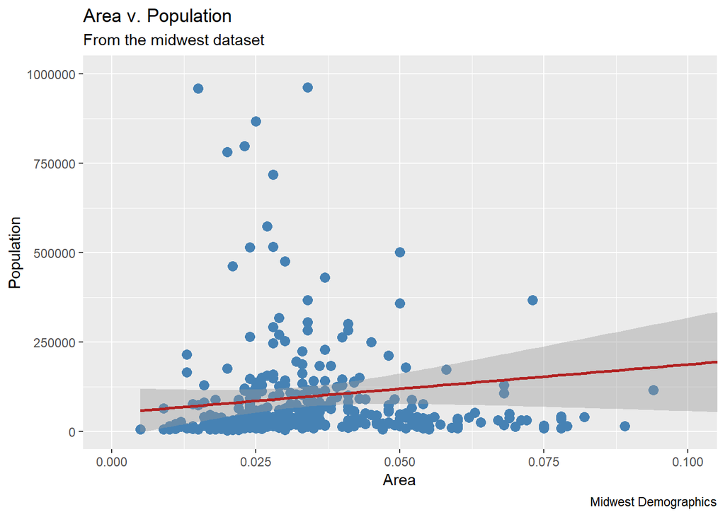

```r
g0 = ggplot(midwest, aes(x = area, y = poptotal))
g0 + geom_point(col = "steelblue", size = 3) +    # Label scatterplot points with color 'steelblue' & size 3
  geom_smooth(method = "lm", col = "firebrick") + # Draw the regression line with the color 'firebrick'
  coord_cartesian(xlim = c(0, 0.1), ylim = c(0, 1000000)) + labs(title = "Area v. Population", subtitle = "From the midwest dataset", x = "Area", y = "Population", caption = "Midwest Demographics")
```

The aesthetics function within geometries can attach features (e.g. color,size, shape, stroke, fill) to the layer based on the data:

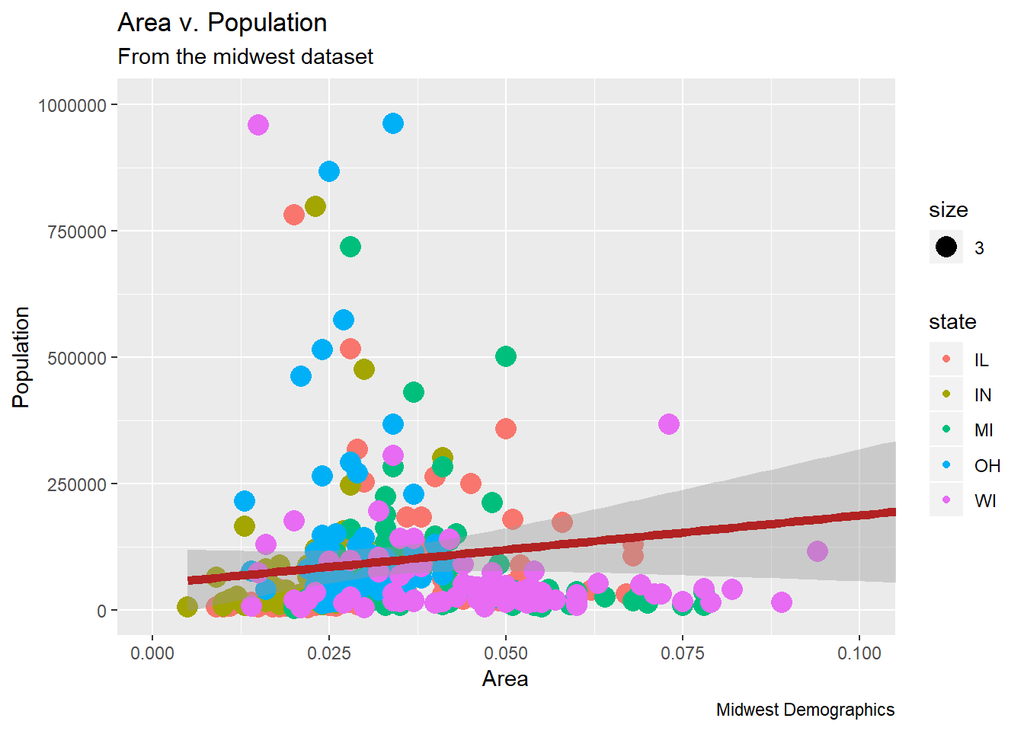

```r
gg = g0 + geom_point(aes(col = state, size = 3)) +
  geom_smooth(method = "lm", col = "firebrick", size = 2) + # Change thickness of regression line
  coord_cartesian(xlim = c(0, 0.1), ylim = c(0, 1000000)) + labs(title = "Area v. Population", subtitle = "From the midwest dataset", x = "Area", y = "Population", caption = "Midwest Demographics")
gg
```

Legends drawn by the aestheics within the geometries can be removed:

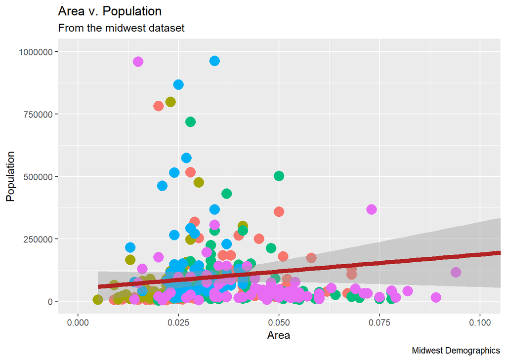

```r
gg + theme(legend.position = "None")  # Remove legend
```

```r
colors()
```

Some popular colors are:

- steelblue4
- firebrick
- tomato
- skyblue
- olivedrab
- forestgreen
- gold
- dodgerblue
- dimgray
- darkred
- darkorange
- darkgray
- springgreen
- violetred
- slateblue
- sienna
- seagreen
- sandybrown
- salmon
- saddlebrown
- maroon
- limegreen

The color palette can be changed completely:

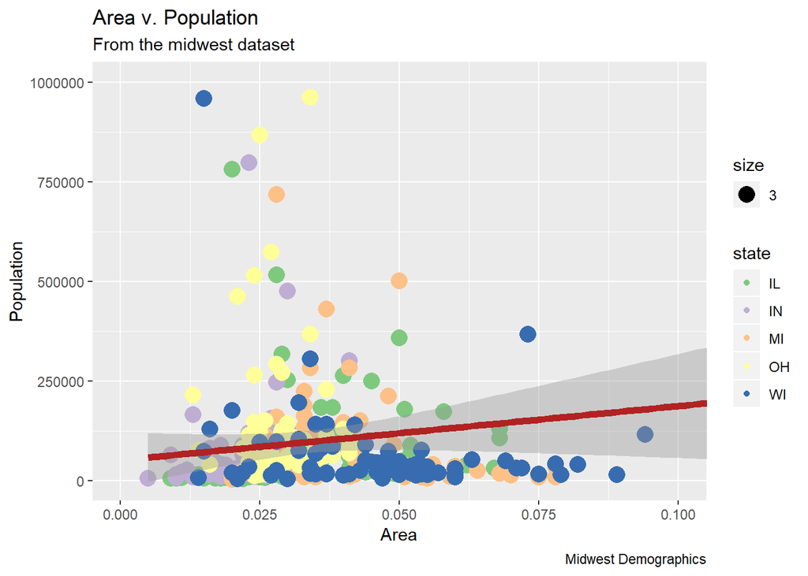

```r
gg + scale_colour_brewer(palette = "Accent")
```

### The Axes

Different geometries can be added to manipulate the axes’ values and aesthetics depending on the type of data represented by each axis.

- scale_x_continuous(): x-axis contains continuous values
- scale_y_date(): y-axis contains date values
- scale_x_log10(): x-axis contains log base 10 values

Available scales are on the ggplot reference page: https://ggplot2.tidyverse.org/reference/

The increments of the axes ticks are controlled by **breaks** and the text is controlled by **labels**:

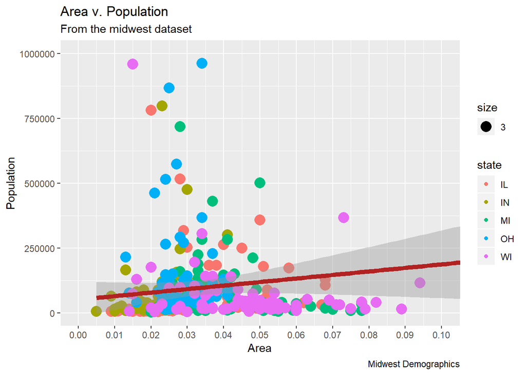

```r
gg = g0 + geom_point(aes(col = state, size = 3)) +
  geom_smooth(method = "lm", col = "firebrick", size = 2) +
  coord_cartesian(xlim = c(0, 0.1), ylim = c(0, 1000000)) + labs(title = "Area v. Population", subtitle = "From the midwest dataset", x = "Area", y = "Population", caption = "Midwest Demographics")
gg + scale_x_continuous(breaks = seq(0, 0.1, 0.01)) # Break x-axis into 11 ticks by 0.01
```

Reverse the scale:

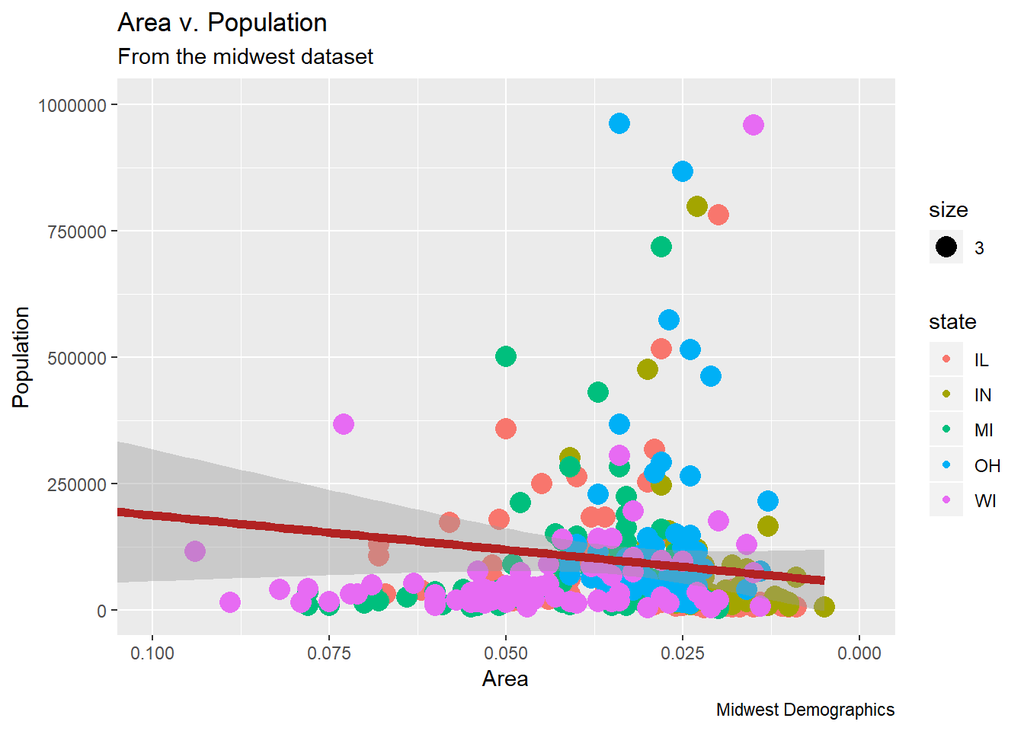

```r
gg + scale_x_reverse() # Reverse the x-axis
```

Change the labels of the x-axis with a vector input to ‘labels’:

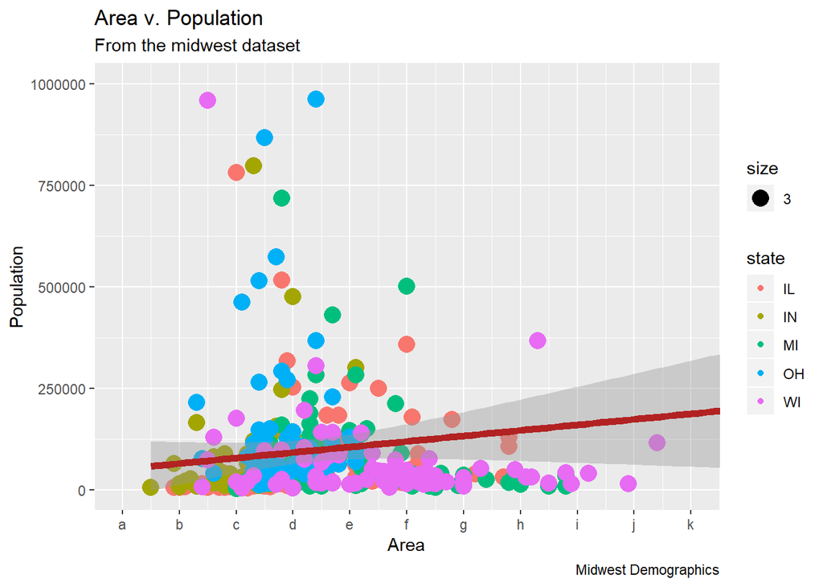

```r
gg + scale_x_continuous(breaks = seq(0, 0.1, 0.01), labels = letters[1:11]) # Label x-axis ticks with values of R array 'letters'
```

Change the labels of the x-axis by formatting the data of the axis:

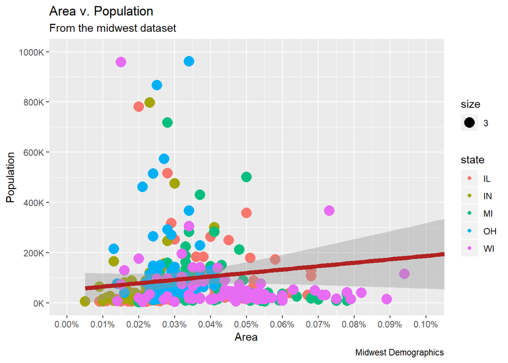

```r
gg + scale_x_continuous(breaks = seq(0, 0.1, 0.01), labels = sprintf("%1.2f%%", seq(0, 0.1, 0.01))) +
  scale_y_continuous(breaks = seq(0, 1000000, 200000), labels = function(x){paste0(x/1000, 'K')})
```